# Взаимосвязи в компании: отчет

Логанова Наталья, niloganova

Загрузка данных

```r
library(igraphdata)
library(igraph)
data(enron)
library(lubridate)
source("~/shared/minor2_2022/2-tm-net/hw/personalTask.R")
start_date = hw_net_get_start_date()
# определяем конечную точку месяца
last_date = start_date + dmonths(1)
time = as_date(as_datetime(E(enron)$Time))
# убираем вершины раньше начальной точки и позже конечной
net = enron %>% delete_edges(E(enron)[time < start_date | time > last_date])
# убираем связи вершины самой с собой (согласно данным, иногда люди себя в копию ставят)
net = simplify(net, remove.multiple = F)
# убираем обособленные вершины
net = net %>% delete_vertices(V(net)[degree(net) == 0])
```

Анализируются данные с 2000-01-31 10:30:00 по 2000-03-01 21:00:00

## Описание сети

Сеть **net** является подграфом сети Enron Email Network и состоит из вершин и ребер, которые находятся в интервале времени между 2000-01-31 10:30:00 и 2000-03-01 21:00:00.

Атрибуты вершин в net соответствуют атрибутам вершин в исходной сети enron и включают:

- Email - адрес электронной почты сотрудника Enron
- Name - имя сотрудника
- Note - должность сотрудника

Атрибуты ребер в net также соответствуют атрибутам ребер в исходной сети enron и включают:

- Time - время отправки письма
- Reciptype - тип адресата (to, cc, bcc)
- Topic - номер топика, к которому отнесено письмо
- LDC_topic - номер темы, к которой отнесено письмо

После обработки сеть net содержит **63 вершин** и **1129 связей**. Также это направленная сеть.

```r
number_of_vertices = vcount(net) # количество вершин
number_of_edges = ecount(net) # количество ребер
```

**Визуализация сети**:

Размер вершин зависит от их степени влиятельности (degree centrality). То есть самым большим будет вершина с наибольшим количеством связей, кому и отправляли (to, cc, bcc), и который больше всех отправлял. Названия вершин - это email адреса. Размер ребер зависит от количества связей между вершинами (веса ребер) и их прозрачности. Визуализация сделана с использованием layout.davidson.harel.

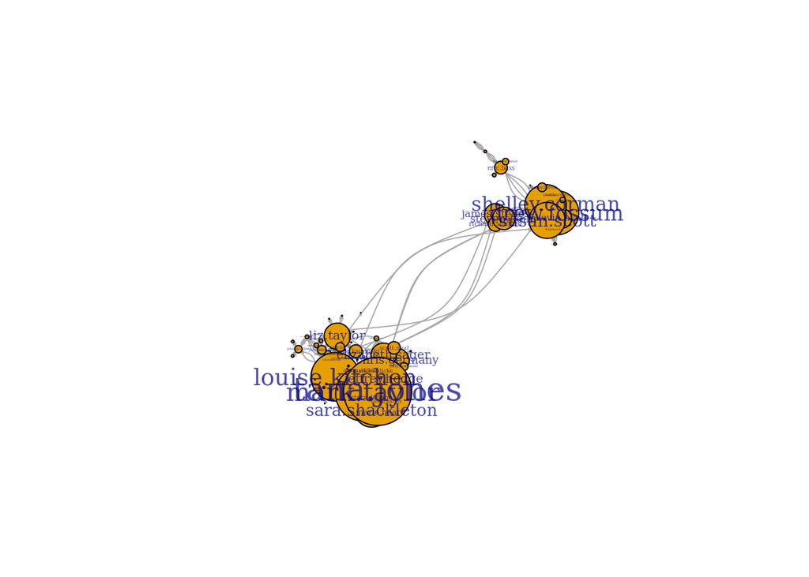

```r
plot(net,
     vertex.size = degree(net)/4,
     vertex.label = V(net)$Email,
     vertex.label.cex = degree(net)/120,
     vertex.label.color = adjustcolor("dark blue", alpha.f = 0.7),
     layout = layout.davidson.harel,
     arrow.size = 0.001,
     edge.arrow.size = 0.1,
     vertex.dist = 200,
     edge.alpha = 0.5,
     edge.width = E(net)$weight/10)
```

### Выявление значимых вершин

**Использованные меры центральности:**

- degree centrality
- betweenness centrality

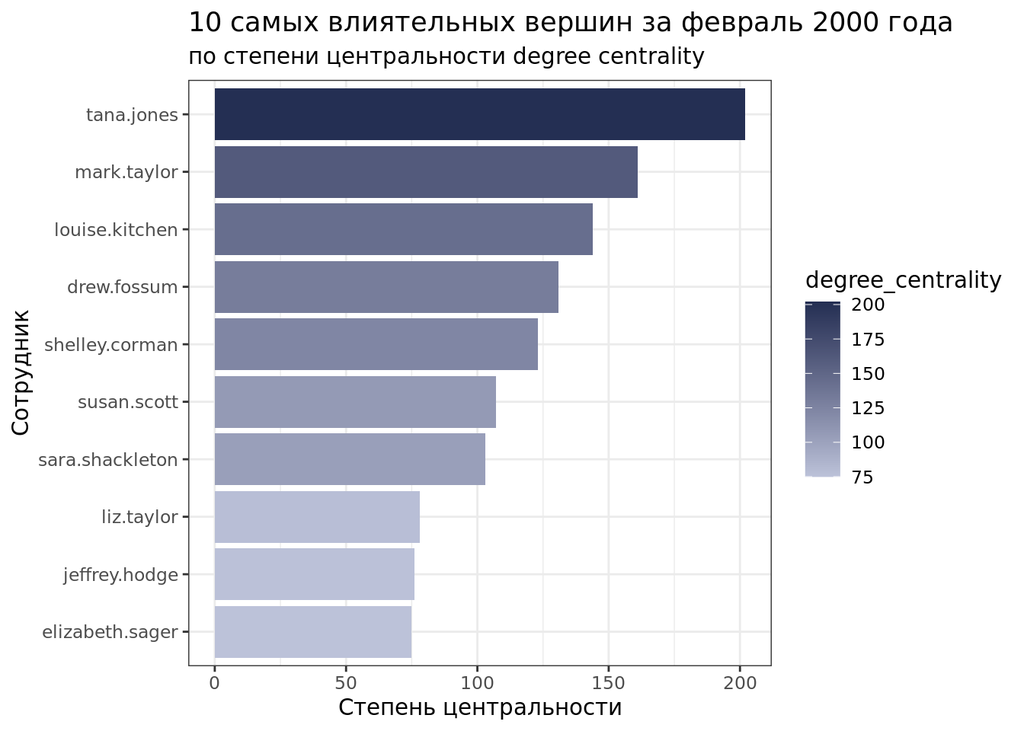

```r
# Вычисляем degree centrality
dc = degree(net)

# Создаем датафрейм с именем вершины и ее degree centrality
df_dc = data.frame(name = V(net)$Email, degree_centrality = dc)

# Сортируем по убыванию degree centrality и берем 10 наиболее центральных вершин
top10_dc = head(df_dc[order(-df_dc$degree_centrality), ], 10)

# Создаем bar plot
library(ggplot2)
ggplot(top10_dc, aes(x = reorder(name, degree_centrality), y =  degree_centrality,fill = degree_centrality)) +
  geom_bar(stat = "identity") +
  labs(x = "Сотрудник", y = "Степень центральности", subtitle = 'по степени центральности degree centrality') +
  coord_flip() +
  theme_bw() +
  ggtitle("10 самых влиятельных вершин за февраль 2000 года") +
  scale_fill_gradient(low = "#BCC2D9", high = "#242F53")
```

Я посмотрела degree centrality по общему количеству отправленных и полученных писем. Самым влиятельным оказался сотрудник **Tana Jones**. Теперь я бы хотела проверить, есть ли различие в том, кто больше всех отправлял и получал email-ы.

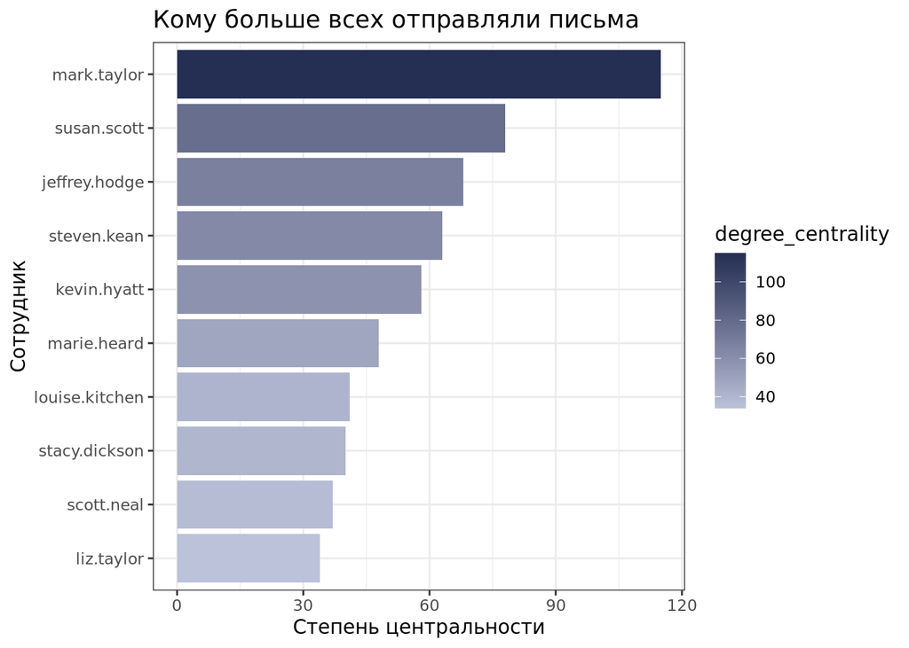

```r
# Вычисляем degree centrality
dc_2 = degree(net, mode = 'in')

# Создаем датафрейм с именем вершины и ее degree centrality
df_dc_2 = data.frame(name = V(net)$Email, degree_centrality = dc_2)

# Сортируем по убыванию degree centrality и берем 10 наиболее центральных вершин
top10_dc_2 = head(df_dc_2[order(-df_dc_2$degree_centrality), ], 10)

# Создаем bar plot
library(ggplot2)
ggplot(top10_dc_2, aes(x = reorder(name, degree_centrality), y =  degree_centrality,fill = degree_centrality)) +
  geom_bar(stat = "identity") +
  labs(x = "Сотрудник", y = "Степень центральности") +
  coord_flip() +
  theme_bw() +
  ggtitle("Кому больше всех отправляли письма") +
  scale_fill_gradient(low = "#BCC2D9", high = "#242F53")
```

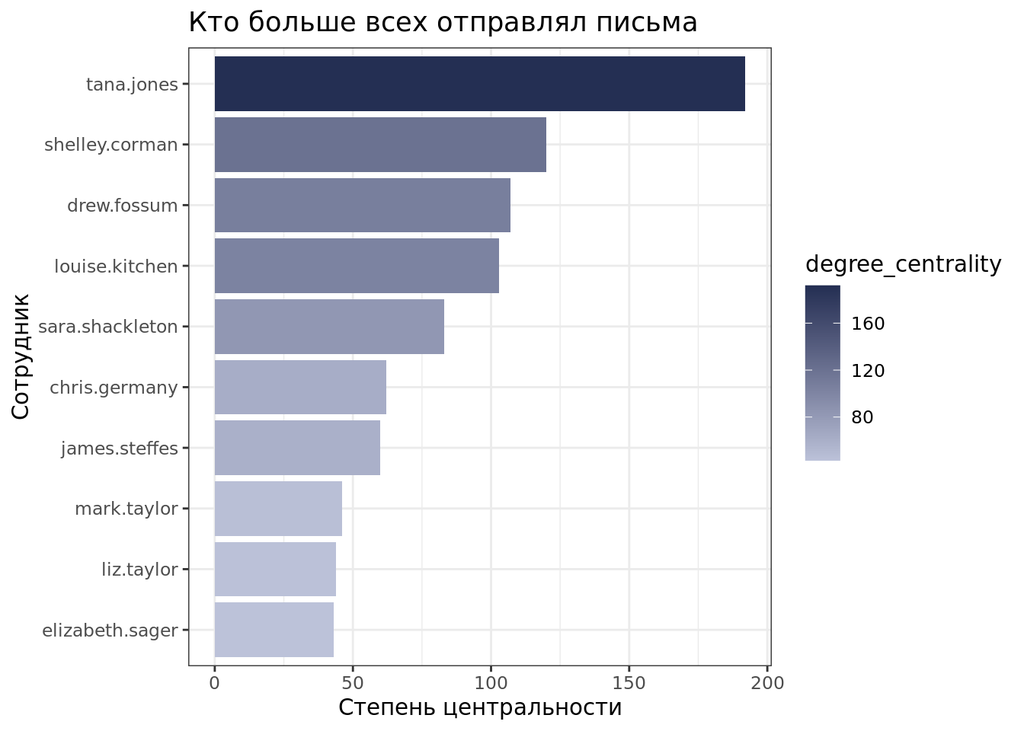

```r
# Вычисляем degree centrality
dc_3 = degree(net, mode = 'out')

# Создаем датафрейм с именем вершины и ее degree centrality
df_dc_3 = data.frame(name = V(net)$Email, degree_centrality = dc_3)

# Сортируем по убыванию degree centrality и берем 10 наиболее центральных вершин
top10_dc_3 = head(df_dc_3[order(-df_dc_3$degree_centrality), ], 10)

# Создаем bar plot
library(ggplot2)
ggplot(top10_dc_3, aes(x = reorder(name, degree_centrality), y =  degree_centrality,fill = degree_centrality)) +
  geom_bar(stat = "identity") +
  labs(x = "Сотрудник", y = "Степень центральности") +
  coord_flip() +
  theme_bw() +
  ggtitle("Кто больше всех отправлял письма") +
  scale_fill_gradient(low = "#BCC2D9", high = "#242F53")
```

Получилось, что больше всех писем отправлял **Tana Jones**, а больше всех получал - **Mark Taylor**, при чем Tana Jones не попал в топ-10 людей, кто больше всех получал, хотя по общему количеству связей этот человек побеждает. Поэтому мне стало интересно, какую должность в компании он занимал, однако информации по этому показателю не оказалось в сети. Может он был спамером, кто рассылал всем сотрудникам, или он работал в информационном отделе.

```r
# Получаем номер вершины, у которой Email равен 'tana.jones'
vertex_id = which(V(net)$Email == 'tana.jones')

# Получаем значение атрибута 'Note' для данной вершины
position = V(net)$Note[vertex_id]
```

Теперь посмотрим, какой сотрудник является самым влиятельным по показателю центральности по битвинности.

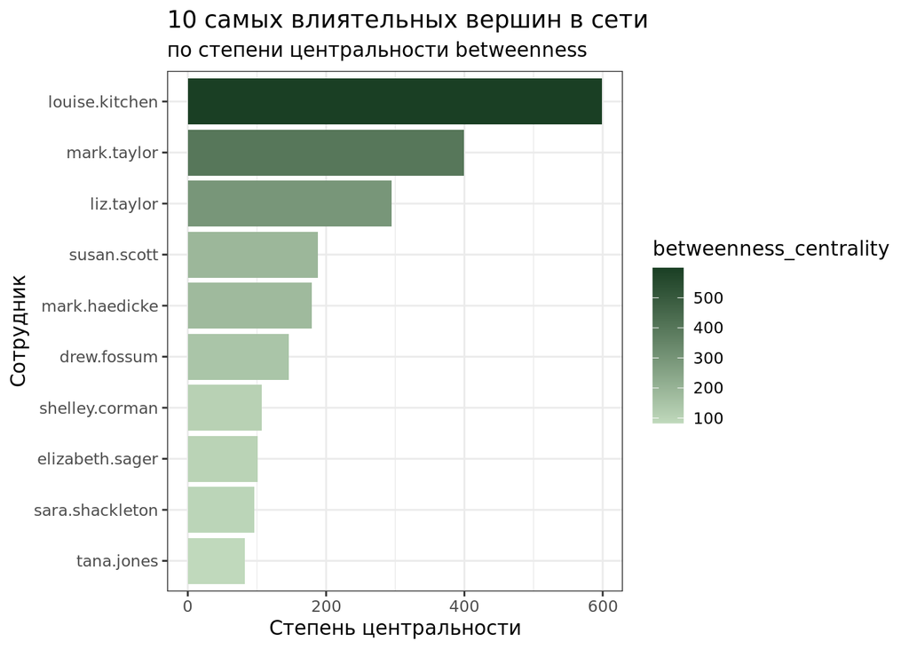

```r
# Вычисляем betweenness centrality
bc = betweenness(net)

# Создаем датафрейм с именем вершины и ее betweenness centrality
df_bc = data.frame(name = V(net)$Email, betweenness_centrality = bc)

# Сортируем по убыванию betweenness centrality и берем 10 наиболее центральных вершин
top10_bc = head(df_bc[order(-df_bc$betweenness_centrality), ], 10)

# Создаем bar plot
library(ggplot2)
ggplot(top10_bc, aes(x = reorder(name, betweenness_centrality), y =  betweenness_centrality, fill = betweenness_centrality)) +
  geom_bar(stat = "identity") +
  labs(x = "Сотрудник", y = "Степень центральности", subtitle = 'по степени центральности betweenness') +
  coord_flip() +
  theme_bw() +
  ggtitle("10 самых влиятельных вершин в сети") +
  scale_fill_gradient(low = "#C0D9BC", high = "#1A3F24")
```

Мера центральности по посредничеству (betweenness centrality) для сети net показывает, какие вершины сети являются ключевыми в пересылке сообщений между другими вершинами. Чем выше значение меры центральности по битвинности для вершины, тем больше кратчайших путей проходит через нее в сети. Таким образом, вершины с более высокой мерой центральности по битвинности играют более важную роль в передаче информации между другими вершинами в сети. Самым влиятельным сотрудником по этому показателю оказался **Louise Kitchen**. Его должность - President, Enron Online.

```r
# Получаем номер вершины, у которой Email равен 'louise.kitchen'
vertex_id2 = which(V(net)$Email == 'louise.kitchen')

# Получаем значение атрибута 'Note' для данной вершины
position2 = V(net)$Note[vertex_id2]
```

### Выявление сообществ

**Использованные меры выделения сообществ:**

- walktrap
- infomap

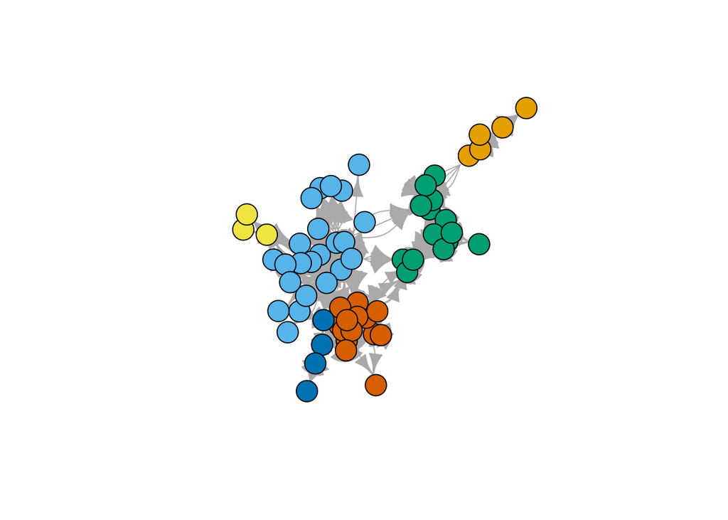

```r
wtcommune = walktrap.community(net)

walktrap_groups = table(membership(wtcommune))

V(net)$wtcommune = membership(wtcommune)
plot(net, vertex.color = V(net)$wtcommune, vertex.label = NA)
```

Walktrap - это подход, основанный на случайных путях. Основная идея – если случайно “блуждать” по графу, то больше шансов, что ваш путь будет чаще оставаться внутри сообщества и только иногда выходить за его пределы. В данном случае это значит, что письма отправляются чаще внутри 6 групп.

Теперь попробую выделить сообщества через метод Infomap.

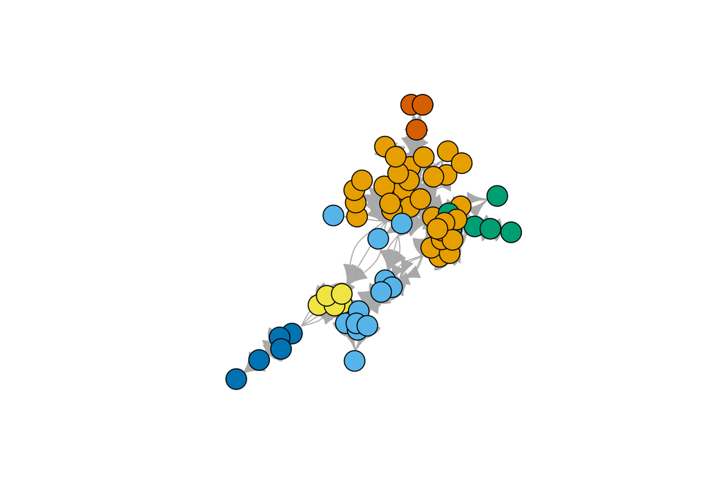

```r
infomap_communities = infomap.community(net)
V(net)$community_infomap = membership(infomap_communities)
plot(net, vertex.color = V(net)$community_infomap, vertex.label = NA)
```

```r
infomap_groups = table(membership(infomap_communities))
```

Infomap пытается найти такое разделение сети на сообщества, которое минимизирует длину кодирования, используемую для описания процесса перемещения в сети. В методе Infomap при выделении сообществ используется алгоритм максимизации модулярности, который определяет количество сообществ и их состав в зависимости от структуры сети и весов ребер. Таким образом, при каждом запуске алгоритма могут получаться разные результаты. В этих данных количество групп получалось 7, 8, 10 и 12.

### Исследовательские вопросы

**Вопрос 1:** правда ли, что внутри группы общаются преимущественно на 1 тему?

Посмотрим, какие темы есть по атрибуту LDC_topic

```r
table(E(net)$LDC_topic)
```

```
##
##  -1   0
## 414 715
```

Есть только значения 0 и -1, которые значат, что письмо не относится ни к одному из выделенных топиков, слишком мало слов в сообщении или что слов в сообщении достаточно, но письмо не удалось отнести ни к одной из 32 тем. Это нам не поможет, поэтому посмотрим, какие темы выделены по атрибуту Topic:

```r
table(E(net)$Topic)
```

```
##
##   0   1   2   3
##  24 582  37 486
```

Уже хорошо, так как есть целых 3 выделенных темы. Топик = 0 значит, что письмо не относится ни к одному из выделенных топиков.

Буду рассматривать выделенные ранее группы по методу walktrap.

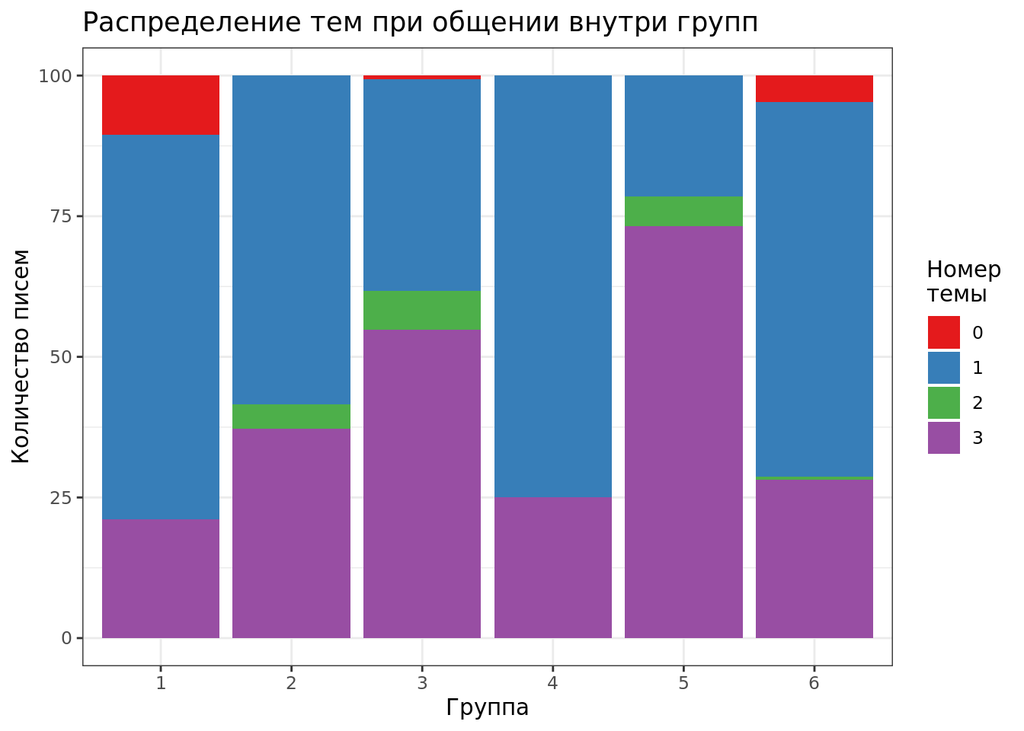

```r
library(igraph)
library(dplyr)

edge_list <- get.data.frame(net, what = "edges")
colnames(edge_list) <- c("From", "To", "Time", "Reciptype", "Topic", "LDC_topic")

a = (1:63)
c = as.vector(membership(wtcommune))

df = data.frame(To = a, Group = c)

edge_list_part = edge_list %>%
  select(From, To, Topic) %>%
  left_join(df, edge_list_part, by = "To") %>%
  rename(Group_To = Group)

df = data.frame(From = a, Group = c)

edge_list_part = edge_list_part %>%
  left_join(df, edge_list_part, by = "From") %>%
  rename(Group_From = Group)

edge_list_part = edge_list_part %>%
  filter (Group_To == Group_From) #удаляю сообщения, которые не внутри одной группы отправлены

edge_list_part = edge_list_part %>%
  select (From, To, Topic, Group_To) %>%
  rename(Group = Group_To)

groups_by_topic = edge_list_part %>%
  group_by (Group, Topic) %>%
  count()

# вычисление общего количества строк в каждой группе
total_counts_by_group <- groups_by_topic %>%
  group_by(Group) %>%
  summarise(total_count = sum(n))

# добавление столбца percent
groups_by_topic <- groups_by_topic %>%
  left_join(total_counts_by_group, by = "Group") %>% # объединение с общим количеством строк в каждой группе
  mutate(Percent = round(n * 100 / total_count, 2))

groups_by_topic_percent = groups_by_topic %>%
  select (Group, Topic, Percent)

groups_by_topic_percent$Topic = as.character(groups_by_topic_percent$Topic)

ggplot(groups_by_topic_percent, aes(x = factor(Group), y = Percent, fill = Topic ), position = "dodge") +
  geom_bar(stat = "identity") +
  labs(x = "Группа", y = "Количество писем") +
  ggtitle("Распределение тем при общении внутри групп") +
  scale_fill_brewer(name = "Номер\nтемы", palette = "Set1") +
  theme_bw()
```

Я создала таблицу, в которой каждая строка представляет собой одну связь между вершинами. Таблица содержит столбцы “From”, “To” и “Topic”. Далее, я с помощью функции left_join добавила информацию о том, к какой группе относятся отправитель и получатель. Затем я отобрала только те связи, которые находятся между вершинами, принадлежащими одной и той же группе (потому что я хочу проверить, общаются ли люди внутри одной группы на одну тему). Затем выявила в процентном соотношении, сколько занимает определенная тема в общении внутри каждой группы.

По полученной диаграмме можно увидеть, что в каждой выделенной по методу walktrap группе есть топик, который занимает больше 50% всех связей внутри этой группы. **Значит, можно прийти к выводу, что внутри одной группы люди преимущественно общаются на 1 тему.**

**Вопрос 2:** правда ли, что у сотрудников с большим количеством входящих писем обычно более высокая должность

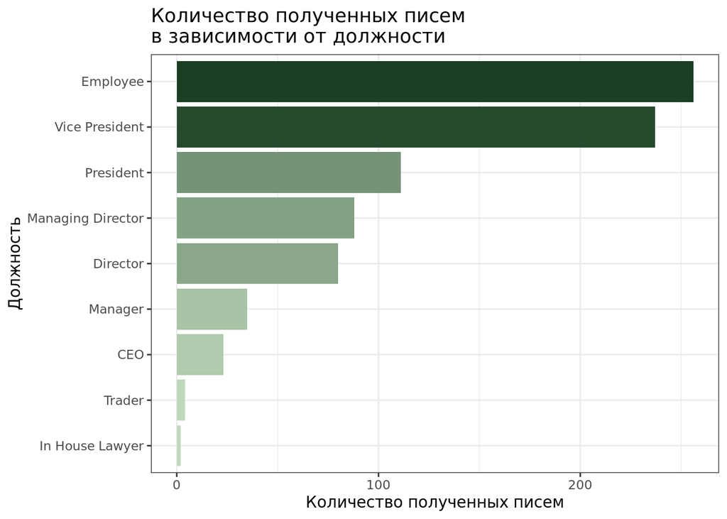

```r
positions = V(net)$Note
df1 = data.frame(To = a, Position = positions)

edge_list_to = edge_list %>%
  select(To) %>%
  left_join(df1, edge_list_to, by = "To")

edge_list_to$Position <- gsub(",.*", "", edge_list_to$Position)

edge_list_to = edge_list_to  %>%
  group_by (Position) %>%
  count() %>%
  filter (Position != 'NA')

ggplot(edge_list_to, aes(x = reorder(Position, n), y =  n, fill = n)) +
  geom_bar(stat = "identity") +
  labs(x = "Должность", y = "Количество полученных писем") +
  coord_flip() +
  theme_bw() +
  ggtitle("Количество полученных писем \nв зависимости от должности") +
  scale_fill_gradient(low = "#C0D9BC", high = "#1A3F24") +
  theme(legend.position = "none")
```

Этот исследовательский вопрос не подтвердился, так как больше всех писем получала позиция “Employee”, а CEO, самая высокая должность в иерархической структуре, занимает 7 место из 9.

**Вывод:** не у самых высокодолжностных работников большее количество входящих писем.

## Место сотрудника в сети

```r
hw_net_get_vertex(net)
```

```
## [1] "Elizabeth Sager"
```

```r
head(arrange(df_dc, -degree_centrality), 10)
```

```
##               name degree_centrality
## 1       tana.jones               202
## 2      mark.taylor               161
## 3   louise.kitchen               144
## 4      drew.fossum               131
## 5   shelley.corman               123
## 6      susan.scott               107
## 7  sara.shackleton               103
## 8       liz.taylor                78
## 9    jeffrey.hodge                76
## 10 elizabeth.sager                75
```

```r
out = degree(net, 8, mode = 'out')
in1 = degree(net, 8, mode = 'in')
```

Сотрудник Elizabeth Sager занимает 10 место по degree centrality. Это значит, что у нее много связей, то есть она много отправляет/получает писем. Ее degree centrality = 75, это значит, что за месяц у нее было столько коммуникации в почте. Она отправляла письма 43 раза, получала - 32.

```r
head(arrange(df_bc, -betweenness_centrality), 10)
```

```
##               name betweenness_centrality
## 1   louise.kitchen               599.1907
## 2      mark.taylor               399.1726
## 3       liz.taylor               294.8173
## 4      susan.scott               188.1391
## 5    mark.haedicke               179.5308
## 6      drew.fossum               145.8609
## 7   shelley.corman               107.0000
## 8  elizabeth.sager               100.9762
## 9  sara.shackleton                96.0000
## 10      tana.jones                82.7619
```

Сотрудник Elizabeth Sager занимает 8 место по betweenness centrality. Это значит, что довольно часто вершина находится на кратчайшем пути между двумя другими вершинами в графе.

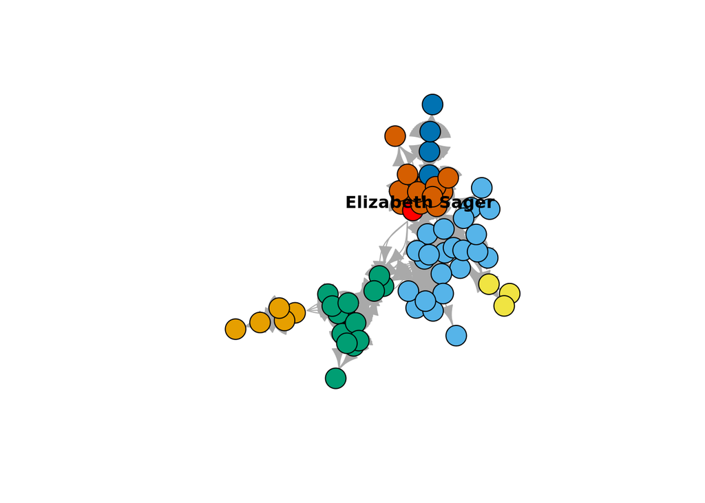

```r
group_es = df$Group[df$From == '8']

V(net)$label <- V(net)$Name

V(net)$wtcommune = membership(wtcommune)

plot(net, vertex.color = ifelse(V(net) == "8", "red", V(net)$wtcommune),
     vertex.label.color = ifelse(V(net) == "8", "black", "white"),
     vertex.label.dist = 1, vertex.label.font = 2, vertex.label.family = "sans",
     vertex.label = ifelse(V(net) == "8", as.character(V(net)$Name), NA),
     vertex.alpha = ifelse(V(net) == "8", 1, 0))
```

Сотрудник Elizabeth Sager принадлежить группе 6 при выделении сообществ через метод walktrap.

```r
position_es = df1$Position[df1$To == '8']
```

Ее должность - “Employee”.

По сотруднику Elizabeth Sager можно сделать вывод, что она довольно часто общалась в феврале 2000 года. Также она связывала кратчайшие пути (путь = письмо). То есть она входила в число влиятельных людей по мерам центральности degree и betweenness. Кроме этого, она входила в группу 6, где преимущественно общались на тему 1.

## Общие выводы

> В результате анализа части сети Enron за месяц февраль было выявлено, что сотрудник Tana Jones является наиболее влиятельным, основываясь на показателе degree centrality. Далее было проведено сравнение количества отправленных и полученных писем, где наибольшим отправителем оказался Tana Jones, а наибольшим получателем - Mark Taylor. Однако, Tana Jones не входит в топ-10 получателей, что вызвало вопросы о его должности в компании.

> Далее были применены различные методы выделения сообществ, такие как Walktrap и Infomap. Walktrap выявил наиболее частые связи внутри 6 групп, а Infomap при каждом запуске давал разное количество сообществ, в данном случае - 7, 8, 10 и 12.

> Было проверено 2 исследовательских вопроса: Внутри одной группы люди преимущественно общаются на одну тему. И количество входящих писем не коррелирует с должностью сотрудника.

> Кроме того, сотрудник Elizabeth Sager является влиятельным членом сети по мерам центральности degree и betweenness, и принадлежит к группе 6, где преимущественно общались на тему 1.

> В заключение хотела бы сказать, что данный анализ позволил получить представление о структуре сети net и ее ключевых участниках.